# Machine Learning for Social Scientists, Part 2: Decision Trees, Random Forests, and Boosting

Author

Heeyoung Lee

Published

August 16, 2026

## Machine Learning for Social Scientists, Part 2

In Part 1 we covered supervised vs. unsupervised learning, the bias-variance tradeoff, and regularized regression (ridge, lasso, elastic net). All of those methods share one thing in common: they’re still built on a straight line, just a heavily disciplined one. This post covers a completely different family of tools — **tree-based methods** — that don’t assume a straight line (or any particular shape) at all. We’ll build up from a single decision tree, to a forest of them, to a method that builds trees one mistake at a time (boosting), and then learn how to interpret models that no longer hand us a simple coefficient. We’ll keep using the same county-level mortality example throughout.

Let’s load the packages we’ll need:

```r
library(dplyr)
library(ggplot2)
library(kableExtra)
library(patchwork)
library(rpart)         # Decision trees
library(rpart.plot)    # Plotting decision trees
library(randomForest)  # Random forests
library(gbm)           # Gradient boosting
library(pdp)           # Partial dependence plots
library(tidyr)
```

### 1. From Straight Lines to Splits: What Is a Decision Tree?

#### 1-1. The Core Idea

Every method in Part 1 — OLS, ridge, lasso — describes the relationship between predictors and an outcome with a single equation: $Y = \beta_0 + \beta_1 X_1 + \beta_2 X_2 + \dots$. A decision tree throws that assumption away entirely. Instead of a formula, it asks a sequence of yes/no questions and sorts each observation down a branch until it lands in a group with a similar outcome.

This is exactly the “20 questions” game. Think about how a public health researcher might informally reason about a county’s mortality risk without ever running a regression: “Is the poverty rate above 20%? If yes, is the county rural? If yes, that’s a high-risk group. If no, check the physician density…” A decision tree formalizes exactly this kind of reasoning, except the algorithm decides which question to ask, and in what order, by searching the data for the splits that separate high-mortality counties from low-mortality counties most cleanly.

#### 1-2. A County Health Example

Let’s build a small, realistic dataset and grow an actual tree on it.

```r
set.seed(123)
n_counties <- 400

poverty_rate <- runif(n_counties, 5, 35)
uninsured_rate <- runif(n_counties, 3, 25)
physician_density <- runif(n_counties, 50, 400)
rural <- rbinom(n_counties, 1, 0.4)
obesity_rate <- runif(n_counties, 18, 42)

# Mortality rate driven by a nonlinear combination + a rural interaction
mortality_rate <- 500 +
  6 * poverty_rate +
  4 * uninsured_rate -
  0.3 * physician_density +
  3 * obesity_rate +
  25 * rural * (poverty_rate > 20) +  # rural + high poverty is especially bad
  rnorm(n_counties, 0, 20)

county_df <- data.frame(
  poverty_rate, uninsured_rate, physician_density,
  rural = factor(rural, labels = c("Urban/Suburban", "Rural")),
  obesity_rate, mortality_rate
)

head(county_df, 6) %>%
  kable(digits = 1) %>%
  kable_styling(bootstrap_options = c("striped", "hover", "condensed"))
```

| poverty_rate | uninsured_rate | physician_density | rural | obesity_rate | mortality_rate |
| --- | --- | --- | --- | --- | --- |
| 13.6 | 24.7 | 214.7 | Rural | 33.3 | 696.2 |
| 28.6 | 6.0 | 178.0 | Rural | 21.0 | 709.7 |
| 17.3 | 22.9 | 92.4 | Urban/Suburban | 24.1 | 739.6 |
| 31.5 | 15.7 | 66.4 | Rural | 37.7 | 867.2 |
| 33.2 | 11.7 | 142.0 | Urban/Suburban | 37.3 | 764.4 |
| 6.4 | 12.9 | 389.0 | Rural | 19.1 | 551.2 |

Notice something important about how this data was built: the effect of poverty depends on whether the county is rural. That’s a built-in **interaction**, exactly the kind of pattern that’s clumsy to capture in a linear regression (you’d have to remember to add a poverty × rural interaction term yourself) but that a tree can discover automatically.

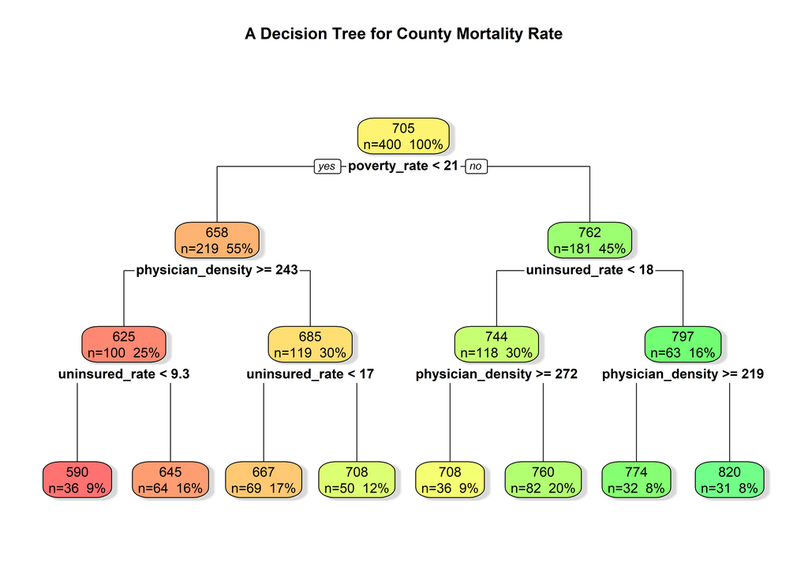

```r
single_tree <- rpart(mortality_rate ~ poverty_rate + uninsured_rate + physician_density + rural + obesity_rate,
                      data = county_df, method = "anova",
                      control = rpart.control(maxdepth = 3, cp = 0.01))

rpart.plot(single_tree, type = 2, extra = 101, fallen.leaves = TRUE,
           box.palette = "RdYlGn", shadow.col = "gray85",
           main = "A Decision Tree for County Mortality Rate")
```

Read this tree from the top down, like a flowchart. Each box asks a yes/no question about a predictor. If the answer is “yes,” you follow the left branch; if “no,” the right branch. You keep following branches until you hit a bottom box (a “leaf”), which gives the predicted mortality rate for counties matching that combination of answers, along with the percentage of counties that land there.

### 2. How Splits Are Chosen, and Why Tree Depth Needs a Leash

#### 2-1. Choosing a Split

At each box in the tree, the algorithm considers every possible question it could ask (every predictor, at every possible cutoff value) and picks the one that makes the two resulting groups as different from each other as possible. For a continuous outcome like mortality rate, “as different as possible” usually means: pick the split that most reduces the variance of mortality within each resulting group.

Think of it like sorting a messy pile of mail into two bins so that each bin is as internally similar as possible. A good first sort (say, by zip code) leaves you with two much more homogeneous piles than a bad one (say, by envelope color).

#### 2-2. Why Depth Needs to Be Limited — the Same Overfitting Problem, New Costume

Here’s where Part 1’s bias-variance lesson comes back, wearing a different outfit. A tree with unlimited depth can keep splitting the data over and over until every single county sits alone in its own leaf, perfectly “predicting” every observation in the training data. This is the tree-based version of the high-degree polynomial from Part 1 — a model so flexible it memorizes the noise instead of learning the signal.

**Tree depth is the regularization parameter for trees**, playing the same role that $\lambda$ played for lasso and ridge in Part 1.

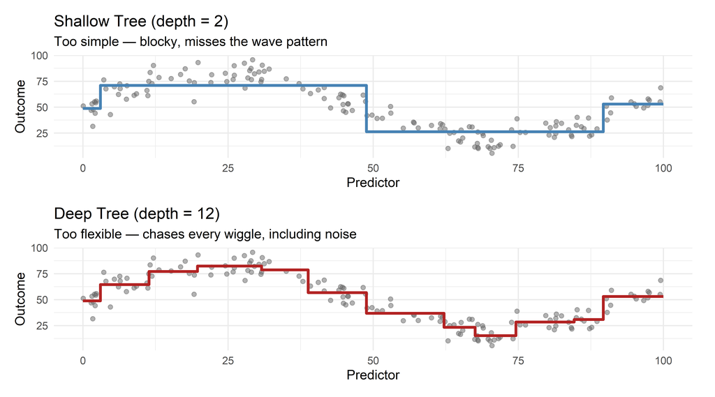

```r
set.seed(2024)
n_sim <- 150
x_sim <- runif(n_sim, 0, 100)
y_sim <- 50 + 30 * sin(x_sim / 15) + rnorm(n_sim, 0, 8)
sim_tree_df <- data.frame(x = x_sim, y = y_sim)

x_grid_tree <- data.frame(x = seq(0, 100, length.out = 300))

shallow_tree <- rpart(y ~ x, data = sim_tree_df, control = rpart.control(maxdepth = 2, cp = 0))
deep_tree <- rpart(y ~ x, data = sim_tree_df, control = rpart.control(maxdepth = 12, cp = 0))

x_grid_tree$shallow_pred <- predict(shallow_tree, newdata = x_grid_tree)
x_grid_tree$deep_pred <- predict(deep_tree, newdata = x_grid_tree)

p_shallow <- ggplot() +
  geom_point(data = sim_tree_df, aes(x, y), alpha = 0.5, color = "gray40") +
  geom_step(data = x_grid_tree, aes(x, shallow_pred), color = "steelblue", linewidth = 1.2) +
  labs(title = "Shallow Tree (depth = 2)", subtitle = "Too simple — blocky, misses the wave pattern",
       x = "Predictor", y = "Outcome") +
  theme_minimal(base_size = 12) +
  theme(plot.margin = ggplot2::margin(8, 15, 8, 8))

p_deep <- ggplot() +
  geom_point(data = sim_tree_df, aes(x, y), alpha = 0.5, color = "gray40") +
  geom_step(data = x_grid_tree, aes(x, deep_pred), color = "firebrick", linewidth = 1.2) +
  labs(title = "Deep Tree (depth = 12)", subtitle = "Too flexible — chases every wiggle, including noise",
       x = "Predictor", y = "Outcome") +
  theme_minimal(base_size = 12) +
  theme(plot.margin = ggplot2::margin(8, 15, 8, 8))

p_shallow / p_deep
```

**The math behind this, simply**: `rpart` doesn’t just count depth — it uses a complexity parameter called $cp$, which works a lot like $\lambda$ from Part 1. Every time the tree considers a new split, that split only survives if it improves the model’s fit by *more* than $cp$:

$$\text{Error before split} - \text{Error after split} > cp$$

- **Large $cp$** → only splits that help a lot are allowed → shallow, simple tree (more bias, less variance)
- **Small $cp$** → even splits that barely help get kept → deep, complex tree (less bias, more variance)
- **$cp = 0$** → no penalty at all → the tree keeps splitting until it perfectly memorizes the training data

This is the exact same idea as the $\lambda R(f)$ penalty from Part 1’s regularization — just phrased as “how much improvement do you need to justify one more split?” instead of “how much do we penalize large coefficients?”

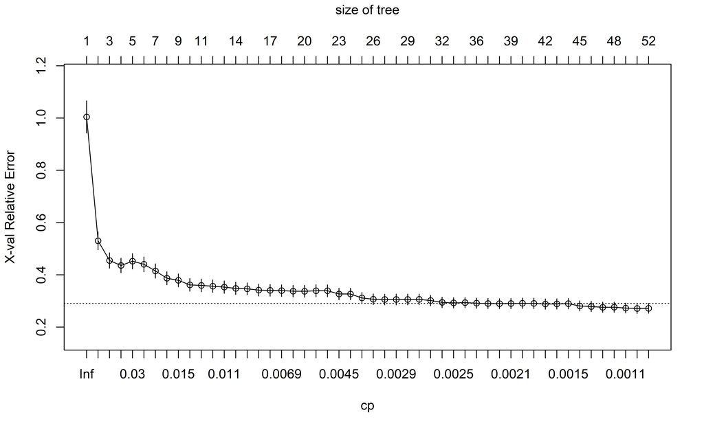

```r
full_tree <- rpart(mortality_rate ~ poverty_rate + uninsured_rate + physician_density + rural + obesity_rate,
                    data = county_df, method = "anova",
                    control = rpart.control(cp = 0.001, minsplit = 10))

plotcp(full_tree)
```

### 3. From One Tree to a Forest: Random Forests

#### 3-1. Why Ask Just One Tree?

A single tree has an appealing property — you can literally draw it and hand it to a colleague. But it has a real weakness: it can be unstable. Change the sample of counties slightly (say, drop 20 counties and add 20 different ones), and the very first split — the one that determines the entire shape of everything below it — might change completely, cascading into a very differently-shaped tree.

The fix is refreshingly simple: **grow many trees instead of one, each on a slightly different version of the data, and average their predictions.** This is called a **random forest**, and it works for the same statistical reason that averaging many noisy measurements gives you a more reliable number than trusting just one.

A random forest adds two sources of randomness on top of an ordinary tree:

1. **Bootstrap sampling**: each tree is grown on a random sample of counties drawn *with replacement* from the full dataset (so some counties appear multiple times, others not at all).
2. **Random predictor subsets**: at each split, the tree is only allowed to consider a random subset of the available predictors, not all of them.

Both kinds of randomness push the individual trees to disagree with each other in different ways, which is exactly what makes their *average* more reliable than any single tree.

```r
set.seed(456)
rf_model <- randomForest(mortality_rate ~ poverty_rate + uninsured_rate + physician_density + rural + obesity_rate,
                          data = county_df, ntree = 500, importance = TRUE)

rf_model
```

```
Call:
 randomForest(formula = mortality_rate ~ poverty_rate + uninsured_rate +      physician_density + rural + obesity_rate, data = county_df,      ntree = 500, importance = TRUE)
               Type of random forest: regression
                     Number of trees: 500
No. of variables tried at each split: 1

          Mean of squared residuals: 1394.342
                    % Var explained: 75.36
```

The output reports the out-of-bag (OOB) error — a built-in, free form of cross-validation. Here’s why it works: each individual tree in the forest is grown on a **bootstrap sample** — a random sample of counties drawn *with replacement*. On average, about one-third of the counties get left out of any given tree’s bootstrap sample entirely (they just never got picked). Those leftover counties are called that tree’s **out-of-bag** counties.

Since that particular tree never saw those counties during training, it can be used to test on them — exactly like a held-out test set, except we didn’t have to set one aside ourselves. Every tree in the forest has its own different set of out-of-bag counties, so by the time all 500 trees are grown, every county in the data has been “held out” and tested on by roughly a third of the trees. Averaging those results gives the OOB error — a legitimate estimate of how well the model would perform on new data, computed automatically as a side effect of how random forests are built, with no extra cross-validation step required.

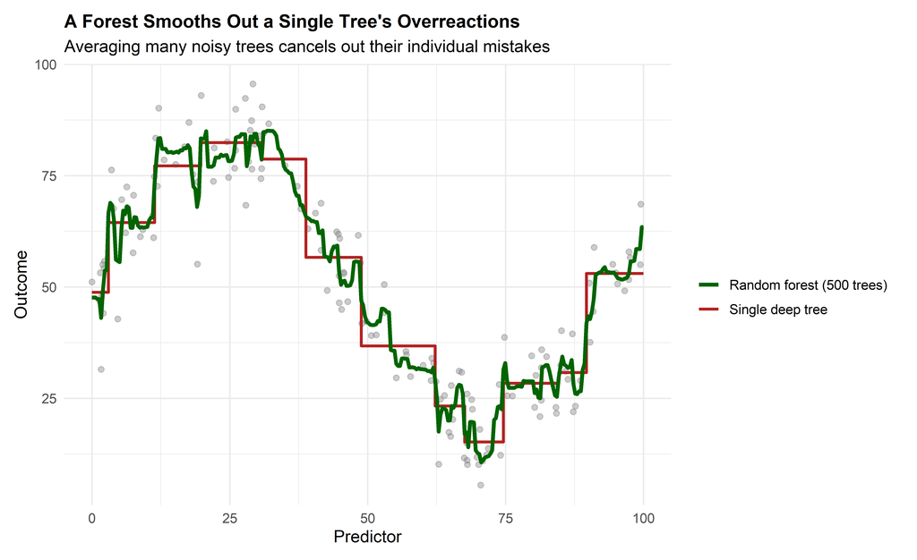

```r
set.seed(789)
rf_sim <- randomForest(y ~ x, data = sim_tree_df, ntree = 500)
x_grid_tree$forest_pred <- predict(rf_sim, newdata = x_grid_tree)

ggplot() +
  geom_point(data = sim_tree_df, aes(x, y), alpha = 0.4, color = "gray50") +
  geom_step(data = x_grid_tree, aes(x = x, y = deep_pred, color = "Single deep tree"), linewidth = 1) +
  geom_line(data = x_grid_tree, aes(x = x, y = forest_pred, color = "Random forest (500 trees)"), linewidth = 1.3) +
  scale_color_manual(values = c("Single deep tree" = "firebrick", "Random forest (500 trees)" = "darkgreen")) +
  labs(title = "A Forest Smooths Out a Single Tree's Overreactions",
       subtitle = "Averaging many noisy trees cancels out their individual mistakes",
       x = "Predictor", y = "Outcome", color = "") +
  theme_minimal(base_size = 12) +
  theme(legend.position = "right",
        plot.title = element_text(face = "bold", size = 13),
        plot.margin = ggplot2::margin(10, 15, 10, 10))
```

**The tradeoff**: we’ve traded away the one thing a single tree had going for it — you can no longer draw a random forest on a whiteboard. A forest of 500 trees is a genuine black box. This sets up the interpretation tools in Section 5.

### 4. Boosting: Learning From Your Mistakes, One Tree at a Time

#### 4-1. A Different Strategy for Combining Trees

Random forests build many trees *independently* and average them — like asking 500 people the same question separately and taking the majority vote. **Boosting** takes a very different approach: it builds trees *sequentially*, where each new tree is trained specifically to fix the mistakes of the trees that came before it.

Here’s the intuition. Imagine a public health researcher building a mortality risk model in stages:

1. Fit a small, simple first tree. It gets the overall pattern roughly right, but makes systematic errors for certain counties (say, it underestimates mortality for rural counties with high uninsured rates).
2. Fit a *second* small tree, not on the original mortality rate, but specifically on the *leftover errors* (residuals) from the first tree — teaching it to correct exactly the mistakes the first tree made.
3. Add the second tree’s predictions to the first tree’s predictions.
4. Repeat: fit a third tree on the residuals that remain after trees 1 and 2, and so on, for hundreds of rounds.

Each individual tree in a boosted model is deliberately kept small and weak (often just a handful of splits) — the power comes from stacking hundreds of these small correction steps on top of each other, not from any single tree being sophisticated.

```r
set.seed(999)
boost_model <- gbm(mortality_rate ~ poverty_rate + uninsured_rate + physician_density + rural + obesity_rate,
                    data = county_df, distribution = "gaussian",
                    n.trees = 1000, interaction.depth = 2, shrinkage = 0.05,
                    cv.folds = 5, verbose = FALSE)

best_iter <- gbm.perf(boost_model, method = "cv", plot.it = FALSE)
cat("Optimal number of boosting rounds (chosen by cross-validation):", best_iter)
```

```
Optimal number of boosting rounds (chosen by cross-validation): 457
```

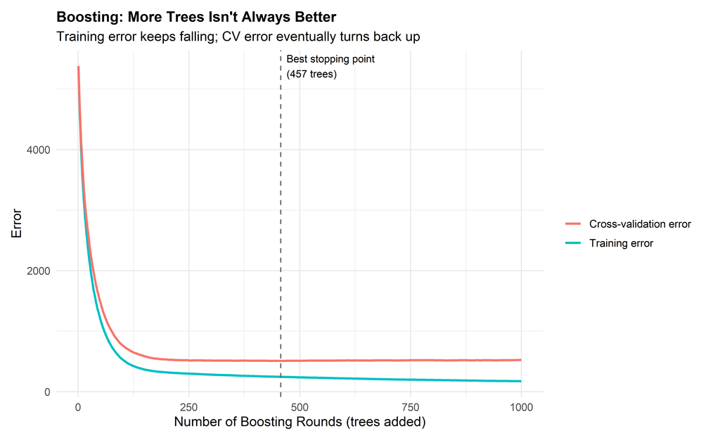

```r
error_df <- data.frame(
  iteration = 1:length(boost_model$train.error),
  train_error = boost_model$train.error,
  cv_error = boost_model$cv.error
)

ggplot(error_df, aes(x = iteration)) +
  geom_line(aes(y = train_error, color = "Training error"), linewidth = 1) +
  geom_line(aes(y = cv_error, color = "Cross-validation error"), linewidth = 1) +
  geom_vline(xintercept = best_iter, linetype = "dashed", color = "gray40") +
  annotate("text", x = best_iter, y = max(error_df$cv_error),
           label = paste0("  Best stopping point\n  (", best_iter, " trees)"),
           hjust = 0, size = 3.3) +
  labs(title = "Boosting: More Trees Isn't Always Better",
       subtitle = "Training error keeps falling; CV error eventually turns back up",
       x = "Number of Boosting Rounds (trees added)",
       y = "Error",
       color = "") +
  theme_minimal(base_size = 12) +
  theme(legend.position = "right",
        plot.title = element_text(face = "bold", size = 13),
        plot.margin = ggplot2::margin(10, 20, 10, 10))
```

This should look familiar — it’s the exact same training-error-versus-test-error picture from Part 1, just with “number of boosting rounds” standing in for “model complexity.” Add too few trees, and the model hasn’t learned enough (underfitting). Add too many, and it starts correcting for noise that isn’t really there (overfitting). The dashed line marks the number of rounds cross-validation says is optimal — this is the boosting equivalent of choosing $\lambda$ in lasso, or tree depth in a single decision tree. It’s the same fundamental lesson from Part 1, showing up for the third time in a new setting.

**Random forest vs. boosting, in one sentence each**: a random forest is many independent trees voting together; boosting is a relay race of trees, where each runner’s whole job is to fix the last runner’s mistakes.

|  | Random Forest | Boosting |
| --- | --- | --- |
| **How trees are built** | Independently, all at once | Sequentially, each fixing the last one’s errors |
| **What controls overfitting** | Bootstrap sampling + random predictor subsets | Learning rate (shrinkage) + number of rounds |
| **Typical tree size** | Deep, fully-grown trees | Shallow, deliberately weak trees |
| **Tuning sensitivity** | Fairly forgiving — hard to badly overfit | More sensitive — too many rounds can overfit |
| **Intuition** | “Wisdom of crowds” — average out independent mistakes | “Relay race” — each runner corrects the last one’s mistake |

Both are answering the exact same underlying question from Part 1 — how much complexity should the model be allowed? — just through different mechanisms: random forest controls it by averaging away instability, while boosting controls it by limiting how many correction rounds it’s allowed to run.

### 5. Opening the Black Box: Variable Importance and Partial Dependence

Random forests and boosted models predict very well, but neither one hands you a clean coefficient like $\hat{\beta} = -1.5$ that you can put in a sentence. If a reviewer asks “so what’s the effect of physician density?”, you need different tools to answer that question. Two of the most useful are variable importance and partial dependence plots.

#### 5-1. Variable Importance: Which Predictors Are Doing the Work?

**The idea, in plain terms**: for each predictor, ask “how much worse do my predictions get if I take this variable away (or scramble it)?” A variable that matters a lot will hurt predictions badly when it’s removed; a variable that doesn’t matter won’t move the needle much.

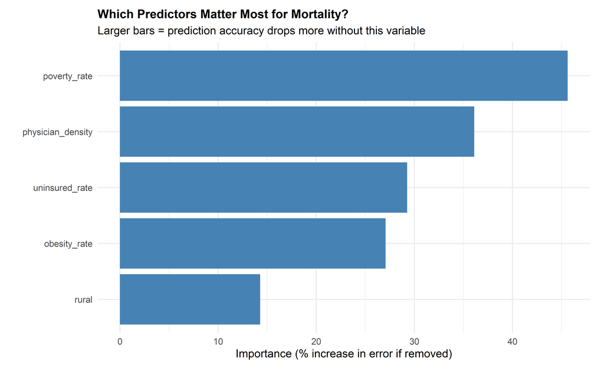

```r
importance_df <- as.data.frame(importance(rf_model)) %>%
  tibble::rownames_to_column("variable") %>%
  arrange(desc(`%IncMSE`))

ggplot(importance_df, aes(x = reorder(variable, `%IncMSE`), y = `%IncMSE`)) +
  geom_col(fill = "steelblue") +
  coord_flip() +
  labs(title = "Which Predictors Matter Most for Mortality?",
       subtitle = "Larger bars = prediction accuracy drops more without this variable",
       x = "", y = "Importance (% increase in error if removed)") +
  theme_minimal(base_size = 12) +
  theme(plot.title = element_text(face = "bold", size = 13),
        plot.margin = ggplot2::margin(10, 15, 10, 10))
```

This ranks our five predictors by how much they contribute to the model’s predictive accuracy. Note the important limitation right away: this tells us *how much* a variable matters for prediction, but not *which direction* it matters in, or whether its effect is a straight line, a curve, or something that only kicks in past a certain threshold. For that, we need the next tool.

#### 5-2. Partial Dependence Plots: What Direction, and What Shape?

**The idea, in plain terms**: pick one predictor you care about — say, poverty rate. Here’s the trick: take a specific poverty rate value, say 20%. Now imagine reaching into the dataset and relabeling *every single county’s* poverty rate to exactly 20% — even the ones that were originally at 5% or 35% — while leaving everything else about each county untouched (its uninsured rate, physician density, rural status, all stay exactly as they really are). Run all 400 of these “modified” counties through the model and get 400 predicted mortality rates. Average those 400 predictions into one number.

That one number is the model’s answer to: “If every county in America had a poverty rate of exactly 20%, what would the average predicted mortality rate be?”

Now repeat the whole exercise at a different poverty rate — say 25% — relabeling all 400 counties again and averaging their new predictions. Then 30%. Then 10%. Do this across a whole range of poverty rate values, and plot the resulting averages against the poverty rate value used. The result is a curve showing how the model’s prediction shifts as poverty rate moves, with every other county characteristic averaged out of the picture. This is what a partial dependence plot (PDP) shows.

This is the tree-based analogue of a regression coefficient — except instead of assuming the relationship is a straight line, we let the data show us its actual shape.

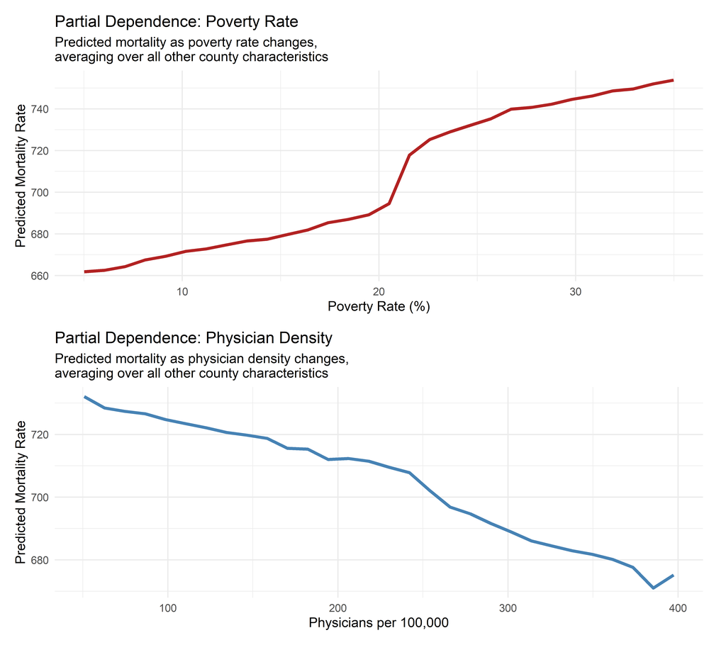

```r
pdp_poverty <- partial(rf_model, pred.var = "poverty_rate", grid.resolution = 30)
pdp_physician <- partial(rf_model, pred.var = "physician_density", grid.resolution = 30)

p_pdp1 <- ggplot(pdp_poverty, aes(x = poverty_rate, y = yhat)) +
  geom_line(color = "firebrick", linewidth = 1.3) +
  labs(title = "Partial Dependence: Poverty Rate",
       subtitle = "Predicted mortality as poverty rate changes,\naveraging over all other county characteristics",
       x = "Poverty Rate (%)", y = "Predicted Mortality Rate") +
  theme_minimal(base_size = 12) +
  theme(plot.margin = ggplot2::margin(8, 15, 8, 8))

p_pdp2 <- ggplot(pdp_physician, aes(x = physician_density, y = yhat)) +
  geom_line(color = "steelblue", linewidth = 1.3) +
  labs(title = "Partial Dependence: Physician Density",
       subtitle = "Predicted mortality as physician density changes,\naveraging over all other county characteristics",
       x = "Physicians per 100,000", y = "Predicted Mortality Rate") +
  theme_minimal(base_size = 12) +
  theme(plot.margin = ggplot2::margin(8, 15, 8, 8))

p_pdp1 / p_pdp2
```

Unlike a regression coefficient, which forces the relationship to be a straight line whether or not that’s realistic, the partial dependence curve is free to bend — and that flexibility is exactly what pays off here. Look closely at the poverty rate curve: it’s not a smooth, steady line. Around 22%, predicted mortality jumps up noticeably faster than it did just below that point. That’s not decoration — it’s the model telling us there may be a **threshold effect**: below roughly 22% poverty, additional poverty seems to matter only modestly, but somewhere past that point, the relationship steepens.

The physician density curve, by contrast, looks comparatively steady across its range in this simulation — but in real applications, that curve is often where a threshold shows up instead: physician density might barely matter once a county is reasonably well-served, but sharply matter below some critical level, once a county becomes genuinely underserved. Whichever variable it shows up in, this is the core advantage of a PDP over a coefficient: it doesn’t just tell you *whether* a predictor matters, but *where* its effect changes shape — something no single number can ever convey.

### 6. Sociological Applications: Risk Prediction and Nonlinear Pattern Discovery

Tree-based methods earn their place in a social scientist’s toolkit through two kinds of tasks that come up constantly in applied research.

#### 6-1. Application 1: Risk Prediction

Many sociological and public health questions are fundamentally about identifying who is at elevated risk, not about estimating a single average effect. A county health department deciding where to target a limited number of mobile health clinics doesn’t need a sentence like “each 1% increase in poverty raises mortality by X” — it needs a ranked list of the counties most likely to need help. Random forests and boosted models are built exactly for this kind of task: they optimize directly for predictive accuracy, which is what risk targeting actually requires.

```r
county_df$predicted_risk <- predict(rf_model, newdata = county_df)

top_risk_counties <- county_df %>%
  arrange(desc(predicted_risk)) %>%
  head(5) %>%
  select(poverty_rate, uninsured_rate, physician_density, rural, obesity_rate, predicted_risk)

kable(top_risk_counties, digits = 1,
      caption = "Five Highest-Predicted-Risk Counties (Simulated Data)") %>%
  kable_styling(bootstrap_options = c("striped", "hover", "condensed"))
```

Five Highest-Predicted-Risk Counties (Simulated Data)

| poverty_rate | uninsured_rate | physician_density | rural | obesity_rate | predicted_risk |
| --- | --- | --- | --- | --- | --- |
| 33.9 | 24.0 | 51.4 | Urban/Suburban | 37.1 | 818.9 |
| 31.5 | 20.7 | 110.6 | Rural | 34.6 | 818.3 |
| 34.3 | 23.5 | 93.4 | Rural | 29.1 | 816.8 |
| 31.5 | 15.7 | 66.4 | Rural | 37.7 | 814.1 |
| 32.4 | 24.5 | 117.0 | Urban/Suburban | 34.3 | 812.0 |

This is precisely the kind of $\hat{Y}$-focused, prediction-culture task from Part 1 — we’re not claiming to have identified *the* causal driver of mortality, only which counties look most vulnerable based on their overall profile.

### 7. How This All Connects Back to Part 1

Every method in this post is, underneath the surface, doing the same thing Part 1’s regularized regressions did — just with a different knob:

| Part 1 concept | Tree-based equivalent |
| --- | --- |
| $\lambda$ (penalty strength) | Tree depth (single tree) |
| Bias-variance tradeoff | Underfitting (shallow tree) vs. overfitting (deep tree) |
| Cross-validation to pick $\lambda$ | Cross-validation to pick tree depth, or number of boosting rounds |
| Shrinking coefficients to reduce variance | Averaging many trees (random forest) to reduce variance |
| A single, interpretable coefficient $\hat{\beta}$ | Variable importance + partial dependence plots (an approximation, not an exact number) |

The specific mechanism changes from method to method, but the underlying logic never does: **more flexibility captures more signal, but also more noise, and the right amount of flexibility is something the data — not the researcher’s intuition — should decide.**

### 8. Conclusion

Tree-based methods complete the supervised learning toolkit we started building in Part 1:

1. **Decision trees** replace a single equation with a sequence of yes/no splits, discovered from the data — including interactions we never had to specify by hand.
2. **Tree depth** is the tree-based version of $\lambda$ from Part 1: too shallow underfits, too deep overfits, and the right depth is chosen by cross-validation.
3. **Random forests** trade away the single tree’s transparency for stability, by averaging hundreds of noisy trees grown on random subsets of the data.
4. **Boosting** builds trees sequentially, each one correcting the last one’s mistakes, and needs its own form of the same complexity control (number of rounds, chosen by cross-validation).
5. **Variable importance and partial dependence plots** let us partially re-open the black box these methods create — telling us which predictors matter, and what shape their relationship with the outcome takes.
6. In applied sociology and public health, these methods shine at **risk prediction** (a pure $\hat{Y}$ task) and as an **exploratory diagnostic** for nonlinearities and interactions worth building into a final, interpretable causal model.

In the next post, we’ll shift from predicting a continuous outcome (mortality rate — any number, on a smooth scale) to predicting a category instead: is this county high-risk or not? Did the county adopt the policy or not? That shift changes more than just the outcome variable — it calls for a different toolkit entirely, starting with logistic regression and k-nearest neighbors, and a whole new set of ways to check whether a model is any good (accuracy alone won’t cut it — we’ll need tools like confusion matrices, precision, recall, and ROC curves). We’ll ground it, as always, in the same kind of county-level questions this series has used throughout: which counties are likely to cross a risk threshold, and how confident should we be in that call?